# Statistics: The Science of Decisions

## *Statistical Analysis of Stroop Effect*

### Background on Stroop Effect

The Stroop effect is a psychological occurrence which was first described by [John Ridley Stroop](https://en.wikipedia.org/wiki/John_Ridley_Stroop) in the article “Studies of interference in serial verbal reactions” (1935) Stroop J.R. Journal of Experimental Psychology 18: 643-622. It is a demonstration of interference in reaction time of a task.

### Design of Experiment

In a stroop task participants are presented with a list of words, with each word displayed in a colour of ink. The participants task is to say out loud the *colour of the ink* in which the word is printed. The task has two conditions:

- *Congruent* words condition: The words being displayed are colour words whose names match the colour in which they are printed, for example RED, BLUE.
- *Incongruent* words condition: The words being displayed are colour words whose names do not match the colour in which they are printed, for example PURPLE, ORANGE.

In each case, the time taken by each participant to name the colour of the ink is measured and recorded.

Experimental design used is within-subject design as the same participant is exposed to more than one condition.

### Identifying the variables

The experimental setup of the given stroop task varies the conditions of the task, namely, *Congruent* words condition and *Incongruent* words condition and measures the time taken by each participant to complete the task. Thus, the independent and dependent variables are as follows:

- **Independent Variable:** Whether the printed word and colour of the ink are the same or different (*Congruent* or *Incongruent*)
- **Dependent Variable:** Time taken to name the colour of the ink of a list of words (*Reaction Time*)

### Formulating hypotheses (H<sub>o</sub> and H<sub>a</sub>)

We can formulate a non-directional set of hypotheses or a directional set of hypotheses.

**Non-Directional**

**H<sub>o</sub>:** The true population mean difference in Reaction time for the test conditions (i.e. *Congruent* and *Incongruent* condition) is equal to zero.  
$\mu$<sub>difference</sub>$=0$ or $\mu$<sub>incongruent</sub>$=\mu$<sub>congruent</sub>

**H<sub>a</sub>:** The true population mean difference in Reaction time for the test conditions is not equal to zero.  
$\mu$<sub>difference</sub>$\ne0$ or $\mu$<sub>incongruent</sub>$\neq\mu$<sub>congruent</sub>

**Directional**

**H<sub>o</sub>:** The true population mean difference in Reaction time for the test conditions is less than or equal to zero.  
$\mu$<sub>difference</sub>$\leq0$ or $\mu$<sub>incongruent</sub>$\leq\mu$<sub>congruent</sub>

**H<sub>a</sub>:** The true population mean difference in Reaction time for the test conditions is greater than zero.  
$\mu$<sub>difference</sub>$>0$ or $\mu$<sub>incongruent</sub>$>\mu$<sub>congruent</sub>

where,  
$\mu$<sub>incongruent</sub> = Population mean reaction time for incongruent condition,  
$\mu$<sub>congruent</sub> = Population mean reaction time for congruent condition,  
$\mu$<sub>difference</sub> = $\mu$<sub>incongruent</sub>$-\mu$<sub>congruent</sub>

The advantage of using a directional hypothesis is in increased power to detect the specific effect we are interested in. The disadvantage is that there is no power to detect an effect in the opposite direction.

### Statistical significance test

The selection of a statistal significance test depends on following factors:

1. **Number of samples:**  
   Since the number of samples in the experiment described above is equal to 2, we can either do a two sample z-test or a two sample t-test.
2. **Sample size:**  
   If the sample size is large enough (>30), we can calculate an estimate of the population standard deviation from sample and perform a z-test. But if the sample size is small (<30) then our estimate of population standard deviation from sample may not be a good estimate. So, we go for a t-test.
3. **Design of Experiment:**  
   Since the experiment described above is designed to be within-subject, we need to perform either a two sample *dependent* z-test or a two sample *dependent* t-test depending on the sample size.

#### Read in the data

```r
stroop_data <- read.csv("stroopdata.csv")
str(stroop_data)
```

```
## 'data.frame':    24 obs. of  2 variables:
##  $ Congruent  : num  12.08 16.79 9.56 8.63 14.67 ...
##  $ Incongruent: num  19.3 18.7 21.2 15.7 22.8 ...
```

```r
head(stroop_data)
```

```
##   Congruent Incongruent
## 1    12.079      19.278
## 2    16.791      18.741
## 3     9.564      21.214
## 4     8.630      15.687
## 5    14.669      22.803
## 6    12.238      20.878
```

The data is structured in 24 rows and 2 columns. Each row corresponds to a participant while each column corresponds to a test condition. So, each row is an observation for a given participant.

#### Summary Statistics

```r
d <- setNames(as.data.frame(rbind(cbind(stroop_data$Congruent,"Congruent"),
                         cbind(stroop_data$Incongruent,"Incongruent"))),
              c("task.completion.time","condition"))

d$task.completion.time <- as.numeric(as.character(d$task.completion.time))

stats <- as.data.frame(
    list(
      Min = tapply(d$task.completion.time, d$condition, min),
      Median = tapply(d$task.completion.time, d$condition, median),
      Mean = tapply(d$task.completion.time, d$condition, mean),
      Max = tapply(d$task.completion.time, d$condition, max),
      StdDev = tapply(d$task.completion.time, d$condition, sd),
      Variance = tapply(d$task.completion.time, d$condition, var)
    )
)
stats['Range'] = stats['Max'] - stats['Min']
stats
```

```
##                Min  Median     Mean    Max   StdDev Variance  Range
## Congruent    8.630 14.3565 14.05113 22.328 3.559358 12.66903 13.698
## Incongruent 15.687 21.0175 22.01592 35.255 4.797057 23.01176 19.568
```

#### Data Visualization

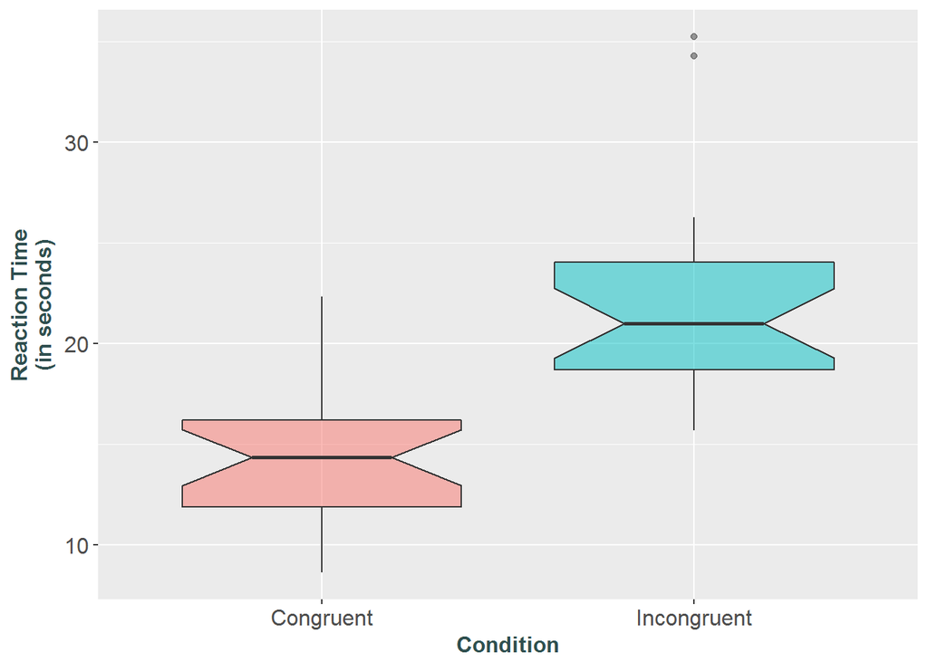

```r
p <- ggplot(d, aes(x = condition, y = task.completion.time))


p +
  geom_boxplot(aes(fill = condition), alpha = 0.5, notch = TRUE) +
  xlab("Condition") +
  ylab(paste("Reaction Time","(in seconds)",sep = '\n')) +
  theme(axis.title = element_text(face = "bold", size = 12, colour = "darkslategrey"),
        axis.text = element_text(size = 12)) + guides(fill=FALSE)
```

The boxplot indicates that the median reaction time for incongruent condition is greater than that of congruent condition. And, since the notches for the two boxes do not overlap, the difference between the medians can be described as *statistically significant at a level of significance of 0.05*. It also indicates that there are two outliers in incongruent condition.

The data can also be visualized as a density plot or a histogram.

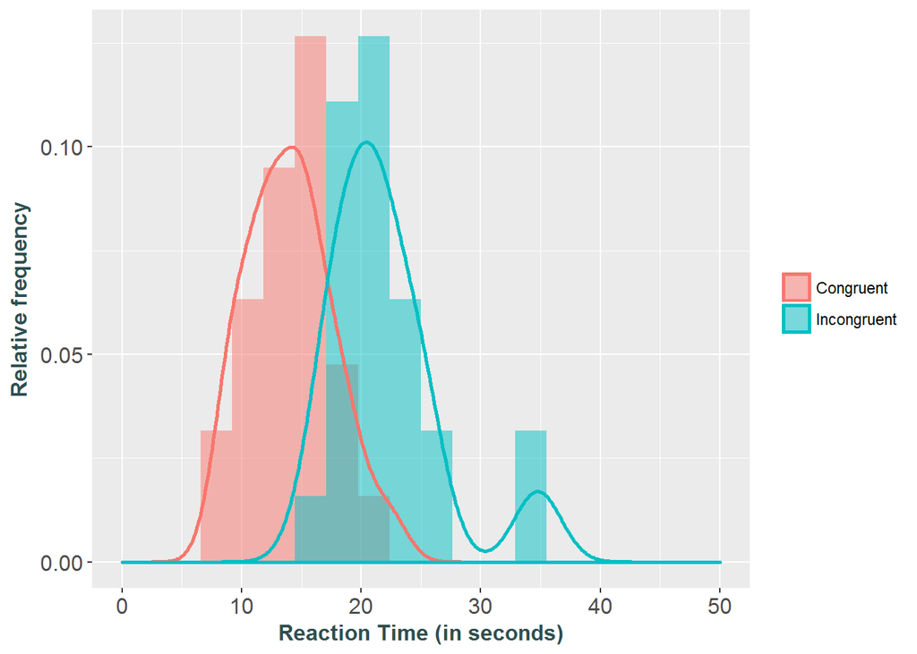

```r
p +
  geom_histogram(aes(x = task.completion.time, y = ..density.., fill = condition),
                 alpha = 0.5, position = 'identity', bins = 20) +
  geom_density(aes(x = task.completion.time, y = ..density..,
                   color = condition),
               alpha = 0,
               size = 1) +
  xlim(c(0,50)) + xlab("Reaction Time (in seconds)") + ylab("Relative frequency") +
  theme(axis.title = element_text(face = "bold", size = 12, colour = "darkslategrey"),
        axis.text = element_text(size = 12),
        legend.title = element_blank())
```

#### Significance test

Since the sample size of our data is less than 30, we will perform a two sample dependent t-test and we will test the directional set of hypotheses.

**1. Calculate difference in reaction time for each paricipant**

```r
stroop_data['diff'] <- stroop_data$Incongruent - stroop_data$Congruent
head(stroop_data)
```

```
##   Congruent Incongruent   diff
## 1    12.079      19.278  7.199
## 2    16.791      18.741  1.950
## 3     9.564      21.214 11.650
## 4     8.630      15.687  7.057
## 5    14.669      22.803  8.134
## 6    12.238      20.878  8.640
```

**2. Test for normality**

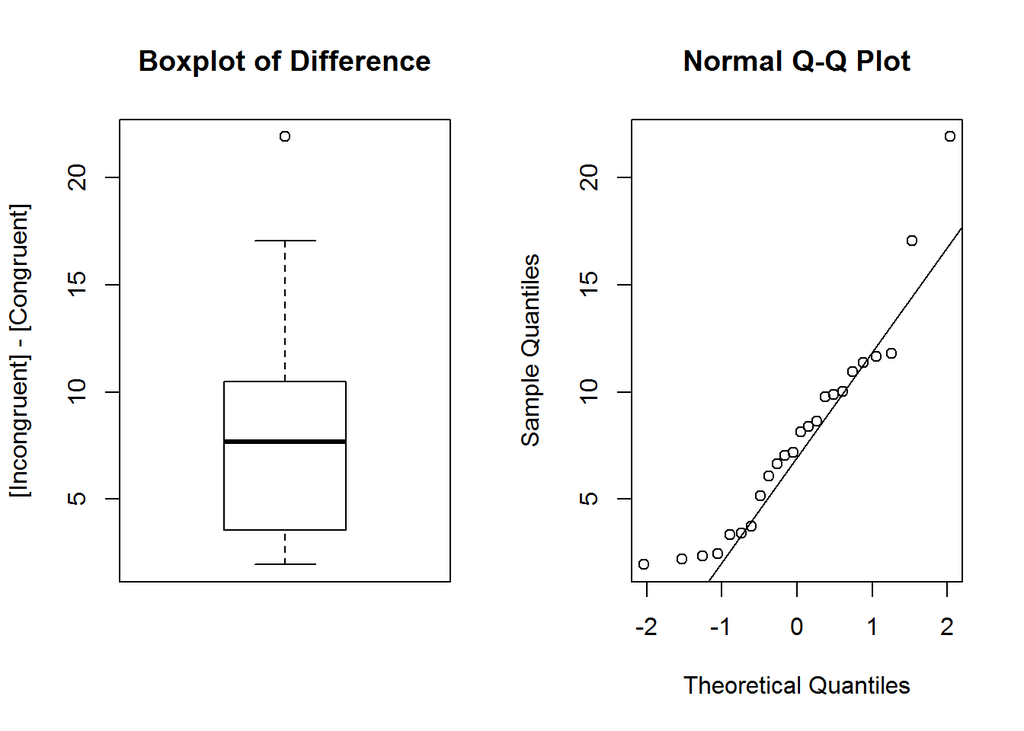

```r
par(mfcol = c(1,2))
boxplot(stroop_data$diff,
        main = "Boxplot of Difference",
        ylab = "[Incongruent] - [Congruent]")
qqnorm(stroop_data$diff)
qqline(stroop_data$diff)
```

The boxplot and the QQ plot indicates that there is some skew, but mostly the plot shows normality.

**3. t-Test**

```r
alpha = 0.01                                         #Significance level

n <- 24                                              #Sample size
df <- n-1                                            #Degrees of freedom

t_c = qt(alpha, df)                                  #t-critical value

x_bar <- sum(stroop_data$diff)/n                     #Mean difference in reaction time
sigma <- sqrt((sum((stroop_data$diff-x_bar)^2))/df)  #StdDev of difference in rection time

se <- sigma/sqrt(n)                                  #Standard error

t <- (x_bar-0)/se                                    #t-Statistic
p <- 2*pt(q = -abs(t), df = df)                      #p-value

cat("t-statistic:",t,'\n',"t-critical:",abs(t_c))
```

```
## t-statistic: 8.020707
##  t-critical: 2.499867
```

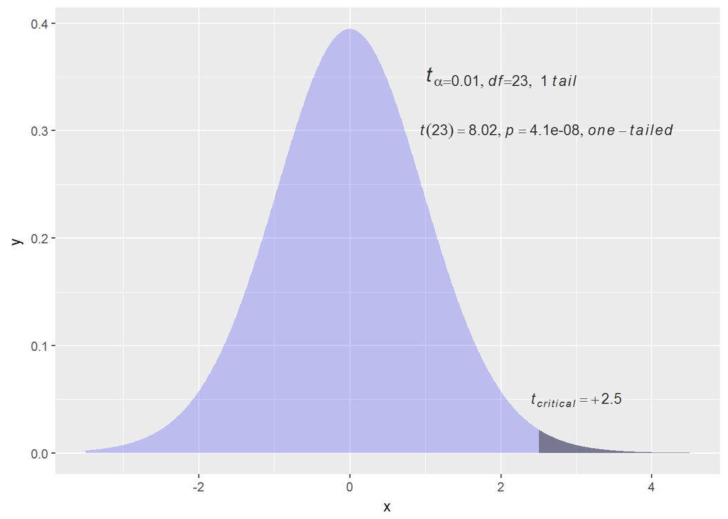

```r
x = seq(-3.5, 4.5, length=10^3)
y = dt(x, df)

ggplot() +
  geom_area(aes(x = x, y = y), fill = "blue", alpha = 0.2) +
  geom_area(aes(x = x[x>abs(t_c)], y = y[x>abs(t_c)]), alpha = 0.5) +
  annotate('text', x = 2, y = 0.35,
           label = paste("italic(t[list(alpha==",alpha,",df==",df,",)~1~tail])"),
           parse = TRUE, size=5, alpha = 0.8) +
  annotate('text', x = 3, y = 0.05,
           label = paste("italic(t[critical]==+", round(abs(t_c),2),")"),
           parse = TRUE, size=3.5, alpha = 0.8) +
  annotate('text', x = 2.6, y = 0.3,
           label = paste("italic(list(t(",df,")==",round(t,2),",p==",round(p,10),",one-tailed))"),
           parse = TRUE, size=3.5, alpha = 0.8)
```

#### Results

```r
CI <- x_bar + abs(t_c)*se                 #99% Confidence Interval

cat("Paired t(",df,")=",round(t,2),", p=",round(p,10),", one-tailed",'\n',
    "One-sided Confidence interval on the mean difference; 99% CI = (",round(CI,2),",",Inf,")\n",sep = "")
```

```
## Paired t(23)=8.02, p=4.1e-08, one-tailed
## One-sided Confidence interval on the mean difference; 99% CI = (10.45,Inf)
```

Since our t-statistic lies in the region of rejection, at a confidence level of 99%, we reject the null hypothesis, H<sub>o</sub>. The results match up with the expectation.

#### Conclusion

```r
d <- x_bar/stats$Mean['Congruent']
cat("Participants averaged ",round(d*100,2),"% longer to name ink colours of incongruent words.",sep = "")
```

```
## Participants averaged 56.68% longer to name ink colours of incongruent words.
```

We conclude that the *cognitive ability to read words interferes with the cognitive ability to identify colours*. One possible explanation to the observed data can be that *word processing happens much faster in our brain than colour processing*.

Since the original study, the Stroop effect has been investigated in a variety of ways. One general finding is that the Stroop effect is very robust. For example, the Stroop effect extends to colour-related words (e.g. sky and fire). It extends to non-words that sound like colour words (e.g. wred and bloo). It occurs with the words that are presented suboptimally (dim, faded, small, etc.).

### Reference

- [Background on Stroop Effect](https://www.rit.edu/cla/gssp400/sbackground.html)
- [Stroop effect, Wikipedia](https://en.wikipedia.org/wiki/Stroop_effect)
- [Notched Box Plots](https://sites.google.com/site/davidsstatistics/home/notched-box-plots)
- [Paired sample t-test in R](https://heuristically.wordpress.com/2011/09/28/paired-sample-t-test-in-r/)
- [The Student t Distribution in R](https://www.math.ucla.edu/~anderson/rw1001/library/base/html/TDist.html)
- [Expression in R](http://www.ats.ucla.edu/stat/r/pages/greek_letters.htm)
- [Using annotate function in R](http://stackoverflow.com/questions/15125628/putting-mathematical-symbols-and-subscripts-mixed-with-regular-letters-in-r-ggpl)